# PscoresPlus Package

Revisiting Extended P-scores: A Quantitative and Graphical Toolkit for Interpretation

## Overview

**PscoresPlus** is an R package for summarizing and interpreting treatment hierarchies from network meta-analysis (NMA) using extended P-scores. It aims to help users explore how rankings change when different clinically important values (CIVs) are assumed, including uncertainty in the choice of CIV. The package quantifies hierarchy stability using P-score residuals and Precision of Treatment Hierarchy (POTH). It provides the Area Under the P-score Curve (AUPC) to rank treatments across a range of CIVs and multiple outcomes simultaneously. It also includes graphical tools to compare and visualize treatment hierarchies across outcomes and CIV ranges.

## Installation

```r
# Install from CRAN (when available)
install.packages("PscoresPlus")

# Or install the development version from GitHub
# install.packages("remotes")
remotes::install_github("sofia-tsokani/PscoresPlus")
```

## Loading the Package

```r
library(PscoresPlus)
```

## Datasets

The package includes two built-in datasets from a published network meta-analysis of antipsychotic drugs in schizophrenia (Leucht et al., 2013). Both have been included as `netmeta` objects and contain treatment effects (TE), corresponding standard errors (seTE), treatment comparisons, and study labels. In both cases, treatment effects are expressed as standardized mean differences (SMD).

> Reference: Leucht S, Cipriani A, Spineli L, et al. Comparative efficacy and tolerability of 15 antipsychotic drugs in schizophrenia: a multiple-treatments meta-analysis. Lancet. 2013;382(9896):951–962.  
> https://doi.org/10.1016/S0140-6736(13)60733-3

### Efficacy

A network of **167 RCTs** comparing **15 antipsychotic treatments and placebo** on treatment efficacy (overall change in symptoms as measured with several scales). Although efficacy is inherently beneficial, it is treated as a **harmful outcome**: a greater reduction in symptoms indicates better treatment performance. Treatment effects are expressed as standardized mean differences (SMD).

```r
#import dataset on efficacy outcome
data("efficacy")
```

### Weight Gain

A network of **86 RCTs** comparing **15 antipsychotic treatments and placebo**. This dataset focuses on **weight gain** as a continuous outcome. Weight gain is treated as a **harmful outcome**, so treatments associated with smaller increases in weight are considered more favorable. Treatment effects are expressed as standardized mean differences (SMD).

```r
#import dataset on wight gean outcome
data("weight_gain")
```

## Extended P-scores

### Single Outcome Example

When analysing a single outcome, supply the outcome of interest as a single-element list of the corresponding `netmeta` object, the CIV to be evaluated, and the outcome type ( `"H"` for harmful or `"B"` for beneficial). Set `excel = TRUE` to export the results directly to a timestamped Excel file.

The function provides:

- *Extended P-scores* per treatment
- *Treatment rankings* (1 = best)
- *Precision of Treatment Hierarchy (PoTH)*
- *P-score residuals*

#### Efficacy Outcome

In this example, we compute extended P-scores for a single outcome (efficacy), treating it as a **harmful** outcome with a CIV of **0.5**.

```r
out_eff <- pscore_civs(
  x           = list(efficacy),
  CIVs        = 0.5,
  correlation = NULL,
  type        = "H"
)

out_eff
```

```
#> # A tibble: 16 × 6
#> # Groups:   CIV1 [1]
#>     CIV1 Treatment    Pscore ranking   poth residuals
#>    <dbl> <chr>         <dbl>   <dbl>  <dbl>     <dbl>
#>  1   0.5 AMI       0.0710          2 0.0643   0.0328
#>  2   0.5 ARI       0.00503         7 0.0643  -0.0332
#>  3   0.5 ASE       0.00238        12 0.0643  -0.0359
#>  4   0.5 CLO       0.324           1 0.0643   0.286
#>  5   0.5 CPZ       0.00440         9 0.0643  -0.0338
#>  6   0.5 HAL       0.00388        10 0.0643  -0.0344
#>  7   0.5 ILO       0.0000582      15 0.0643  -0.0382
#>  8   0.5 LURA      0.000213       14 0.0643  -0.0380
#>  9   0.5 OLA       0.0665          3 0.0643   0.0282
#> 10   0.5 PAL       0.0297          6 0.0643  -0.00850
#> 11   0.5 PBO       0              16 0.0643  -0.0382
#> 12   0.5 QUE       0.00476         8 0.0643  -0.0335
#> 13   0.5 RIS       0.0636          4 0.0643   0.0254
#> 14   0.5 SER       0.00384        11 0.0643  -0.0344
#> 15   0.5 ZIP       0.00119        13 0.0643  -0.0370
#> 16   0.5 ZOT       0.0310          5 0.0643  -0.00724
```

#### Weight Gain Outcome

Here we repeat the analysis for weight gain, a harmful outcome, using a CIV of **-0.5**.

```r
data("weight_gain")

out_wg <- pscore_civs(
  x           = list(weight_gain),
  CIVs        = -0.5,
  type        = "H",
  excel = FALSE #setting the excel argument to TRUE allows for exporting results to a timestamped Excel file
)

out_wg
```

```
#> # A tibble: 16 × 6
#> # Groups:   CIV1 [1]
#>     CIV1 Treatment Pscore ranking  poth residuals
#>    <dbl> <chr>      <dbl>   <dbl> <dbl>     <dbl>
#>  1  -0.5 AMI        1.000       6 0.202   0.0958
#>  2  -0.5 ARI        1.000       5 0.202   0.0958
#>  3  -0.5 ASE        1.000       7 0.202   0.0958
#>  4  -0.5 CLO        0.728      14 0.202  -0.176
#>  5  -0.5 CPZ        0.846      12 0.202  -0.0583
#>  6  -0.5 HAL        1.000       2 0.202   0.0958
#>  7  -0.5 ILO        0.775      13 0.202  -0.129
#>  8  -0.5 LURA       1.000       3 0.202   0.0958
#>  9  -0.5 OLA        0.594      16 0.202  -0.310
#> 10  -0.5 PAL        0.999       8 0.202   0.0946
#> 11  -0.5 PBO        1.000       1 0.202   0.0958
#> 12  -0.5 QUE        0.990      10 0.202   0.0860
#> 13  -0.5 RIS        0.996       9 0.202   0.0922
#> 14  -0.5 SER        0.897      11 0.202  -0.00671
#> 15  -0.5 ZIP        1.000       4 0.202   0.0958
#> 16  -0.5 ZOT        0.640      15 0.202  -0.264
```

### Multiple Outcomes Example

When analysing multiple outcomes simultaneously, you must supply:

1. A *list of `netmeta` objects*, one per outcome
2. A *list of CIV vectors*, one per outcome
3. A *correlation matrix* between outcomes
4. A *`type` vector* specifying whether each outcome is harmful (`"H"`) or beneficial (`"B"`)

### Defining the Correlation Matrix

We assume a correlation of **−0.5** between efficacy and weight gain:

```r
cor_mat <- matrix(
  c( 1.0, -0.5,
    -0.5,  1.0),
  nrow   = 2,
  byrow  = TRUE
)
cor_mat
```

```
#>      [,1] [,2]
#> [1,]  1.0 -0.5
#> [2,] -0.5  1.0
```

### Single CIV per Outcome

```r
out1 <- pscore_civs(
  x           = list(efficacy, weight_gain),
  CIVs        = list(0.5, -0.5),
  correlation = cor_mat,
  type        = c("H", "H")
)

out1
```

```
#> # A tibble: 16 × 7
#> # Groups:   CIV1, CIV2 [1]
#>     CIV1  CIV2 Treatment        Pscore ranking   poth residuals
#>    <dbl> <dbl> <chr>             <dbl>   <dbl>  <dbl>     <dbl>
#>  1   0.5  -0.5 AMI       0.0710              2 0.0216   0.0490
#>  2   0.5  -0.5 ARI       0.00503             5 0.0216  -0.0170
#>  3   0.5  -0.5 ASE       0.00236             8 0.0216  -0.0197
#>  4   0.5  -0.5 CLO       0.176               1 0.0216   0.154
#>  5   0.5  -0.5 CPZ       0.000173           13 0.0216  -0.0219
#>  6   0.5  -0.5 HAL       0.00388             6 0.0216  -0.0182
#>  7   0.5  -0.5 ILO       0.00000000145      15 0.0216  -0.0221
#>  8   0.5  -0.5 LURA      0.000213           11 0.0216  -0.0218
#>  9   0.5  -0.5 OLA       0.0000235          14 0.0216  -0.0220
#> 10   0.5  -0.5 PAL       0.0290              4 0.0216   0.00696
#> 11   0.5  -0.5 PBO       0                  16 0.0216  -0.0221
#> 12   0.5  -0.5 QUE       0.00291             7 0.0216  -0.0191
#> 13   0.5  -0.5 RIS       0.0608              3 0.0216   0.0388
#> 14   0.5  -0.5 SER       0.000180           12 0.0216  -0.0219
#> 15   0.5  -0.5 ZIP       0.00119             9 0.0216  -0.0209
#> 16   0.5  -0.5 ZOT       0.000326           10 0.0216  -0.0217
```

### Multiple CIVs per Outcome

You can supply **multiple CIV values** for any outcome. The function evaluates all the CIV combinations. In the example below, weight gain has two CIVs (−0.3 and −0.5), yielding *2 combinations* in total.

```r
out2 <- pscore_civs(
  x           = list(efficacy, weight_gain),
  CIVs        = list(0.5, c(-0.3, -0.5)),
  correlation = cor_mat,
  type        = c("H", "H"),
  excel       = FALSE #setting the excel argument to TRUE allows for exporting results to a timestamped Excel file
)

out2
```

```
#> # A tibble: 32 × 7
#> # Groups:   CIV1, CIV2 [2]
#>     CIV1  CIV2 Treatment   Pscore ranking    poth residuals
#>    <dbl> <dbl> <chr>        <dbl>   <dbl>   <dbl>     <dbl>
#>  1   0.5  -0.3 AMI       6.39e- 2       2 0.00884   0.0525
#>  2   0.5  -0.3 ARI       4.57e- 3       3 0.00884  -0.00677
#>  3   0.5  -0.3 ASE       9.00e- 4       6 0.00884  -0.0104
#>  4   0.5  -0.3 CLO       1.06e- 1       1 0.00884   0.0949
#>  5   0.5  -0.3 CPZ       3.62e- 7      12 0.00884  -0.0113
#>  6   0.5  -0.3 HAL       3.88e- 3       4 0.00884  -0.00747
#>  7   0.5  -0.3 ILO       5.15e-11      15 0.00884  -0.0113
#>  8   0.5  -0.3 LURA      2.10e- 4       8 0.00884  -0.0111
#>  9   0.5  -0.3 OLA       6.84e- 6      11 0.00884  -0.0113
#> 10   0.5  -0.3 PAL       4.98e- 4       7 0.00884  -0.0108
#> # ℹ 22 more rows
```

> Tip: Set the argument `excel = TRUE` to automatically export results to a timestamped Excel file (e.g., `pscore_civs_20260421_221800.xlsx`) in your working directory.

### Understanding the Output

The returned object is of class `"pscore_civs"` and includes the following items:

| Column | Description |
| --- | --- |
| `Treatment` | Treatment label |
| `Pscore` | Raw extended P-score under that CIV combination |
| `ranking` | Rank of the treatment (1 = best) |
| `residuals` | P-score residuals |
| `poth` | Precision of Treatment Hierarchy (PoTH) |

## Visualizing P-scores Across CIVs

The `plot_pscores()` function plots extended P-scores or residual P-scores (default) across a range of CIV values for a single outcome. The top `top_n` treatments are highlighted in colour; a dashed reference line marks the mean P-score or approximately zero for residuals. As with `pscore_civs()`, supply the outcome as a single-element list containing the `netmeta` object, a numeric vector of CIV values to evaluate, and the outcome type (`"H"` for harmful or `"B"` for beneficial).

### Extended P-scores

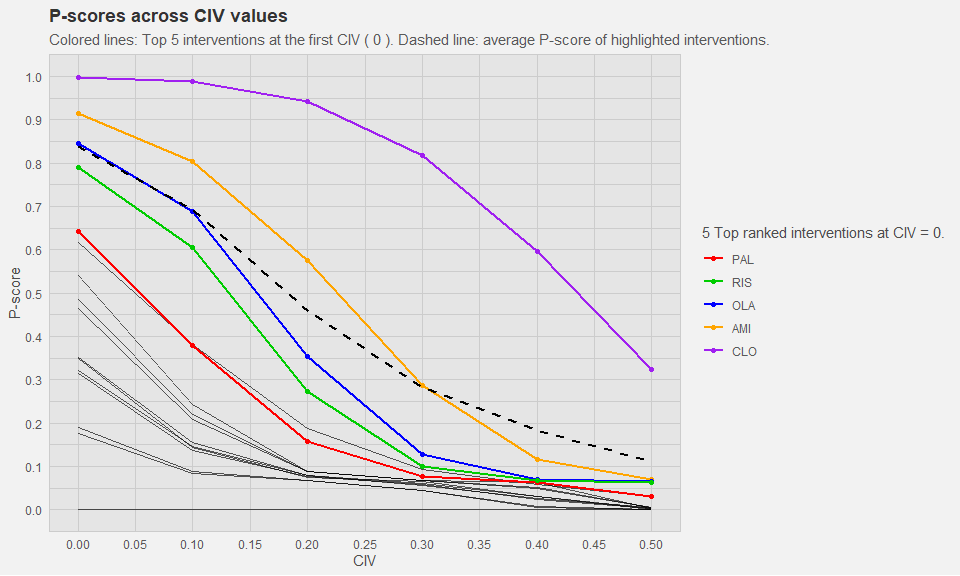

```r
plot_pscores(
  x         = list(efficacy),
  CIVs      = seq(0, 0.5, 0.1),
  type      = "H",
  top_n     = 5,
  residuals = FALSE
)
```

### Residual P-scores

Residual P-scores centre each treatment’s P-score by subtracting the row mean across all treatments at each CIV value.

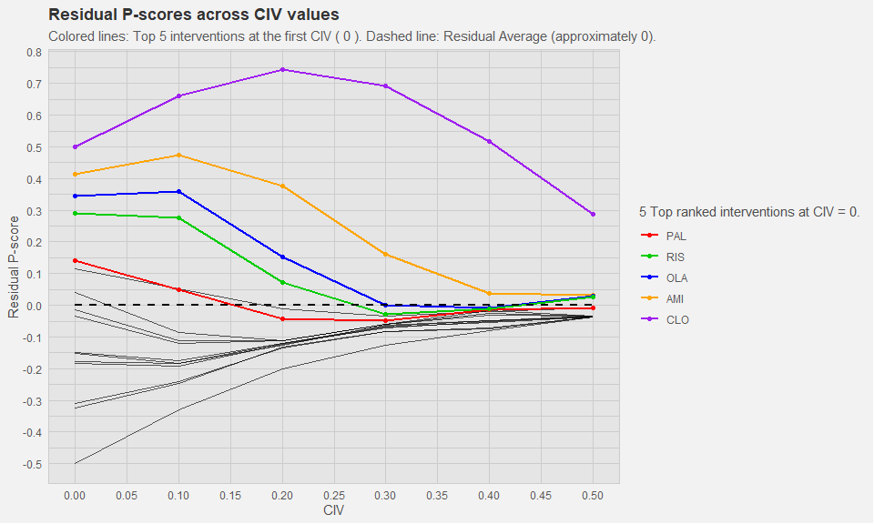

```r
plot_pscores(
  x         = list(efficacy),
  CIVs      = seq(0, 0.5, 0.1),
  type      = "H",
  top_n     = 5,
  residuals = TRUE
)
```

## Area Under the P-score Curve (AUPC)

The `aupc()` function summarises treatment performance across an entire CIV grid by computing the **Area Under the P-score Curve (AUPC)** for each treatment. AUPC can be interpreted as the average probability that a treatment beats all others over the specified range of CIV values. The function takes a `pscore_civs` object as input; set `excel = TRUE` to export results to an Excel file.

### Single Outcome (Efficacy)

```r
#Calculating AUPC for outcome efficacy with a grid of 50 values between 0 and 0.5.
out_eff <- pscore_civs(
  x           = list(efficacy),
  CIVs        = list(seq(0, 0.5, length.out = 50)),
  correlation = NULL,
  type        = "H"
)

aupc(out_eff)
```

```
#>              AUPC Treatment ranking
#> AMI  2.275868e-01       AMI       2
#> ARI  6.357506e-02       ARI       9
#> ASE  4.428284e-02       ASE      13
#> CLO  4.015114e-01       CLO       1
#> CPZ  4.609317e-02       CPZ      12
#> HAL  7.263177e-02       HAL       7
#> ILO  2.774912e-02       ILO      15
#> LURA 2.908459e-02      LURA      14
#> OLA  1.694914e-01       OLA       3
#> PAL  1.012430e-01       PAL       6
#> PBO  2.914975e-09       PBO      16
#> QUE  6.609153e-02       QUE       8
#> RIS  1.475153e-01       RIS       4
#> SER  4.917067e-02       SER      10
#> ZIP  4.747905e-02       ZIP      11
#> ZOT  1.042209e-01       ZOT       5
```

### Single Outcome (Weight Gain)

```r
#Calculating AUPC for outcome weight gain with a grid of 50 values between 0 and 0.5.
out_wg <- pscore_civs(
  x           = list(weight_gain),
  CIVs        = list(seq(-0.5, 0, length.out = 50)),
  correlation = NULL,
  type        = "H"
)

aupc(out_wg)
```

```
#>           AUPC Treatment ranking
#> AMI  0.4587143       AMI       6
#> ARI  0.4697224       ARI       5
#> ASE  0.4468031       ASE       7
#> CLO  0.2206660       CLO      14
#> CPZ  0.2709326       CPZ      12
#> HAL  0.4897395       HAL       2
#> ILO  0.2322807       ILO      13
#> LURA 0.4887501      LURA       3
#> OLA  0.1592023       OLA      16
#> PAL  0.3811620       PAL       8
#> PBO  0.4997852       PBO       1
#> QUE  0.3460598       QUE      10
#> RIS  0.3557255       RIS       9
#> SER  0.2861055       SER      11
#> ZIP  0.4845237       ZIP       4
#> ZOT  0.1751637       ZOT      15
```

### Multiple Outcomes (Efficacy and Weight Gain)

```r
#correlation matrix between the two outcomes (the assumed correlation between efficacy and weight gain is −0.5
cor_mat <- matrix(c( 1.0, -0.5,
                    -0.5,  1.0),
                  nrow  = 2,
                  byrow = TRUE)

out <- pscore_civs(
  x           = list(efficacy, weight_gain),
  CIVs        = list(seq(0, 0.5, length.out = 50),
                     seq(-0.5, 0, length.out = 50)),
  correlation = cor_mat,
  type        = c("H", "H")
)

aupc(out, excel=FALSE) #setting the excel argument to TRUE allows for exporting results to a timestamped Excel file
```

```
#>              AUPC Treatment ranking
#> AMI  9.892843e-02       AMI       1
#> ARI  2.546014e-02       ARI       6
#> ASE  1.467746e-02       ASE       9
#> CLO  8.262265e-02       CLO       2
#> CPZ  4.837522e-03       CPZ      14
#> HAL  3.293874e-02       HAL       4
#> ILO  8.878120e-04       ILO      15
#> LURA 1.226904e-02      LURA      11
#> OLA  2.092671e-02       OLA       7
#> PAL  2.934016e-02       PAL       5
#> PBO  1.443360e-09       PBO      16
#> QUE  1.402522e-02       QUE      10
#> RIS  4.252884e-02       RIS       3
#> SER  6.101354e-03       SER      13
#> ZIP  2.012771e-02       ZIP       8
#> ZOT  1.021084e-02       ZOT      12
```

## Comparing AUPC and P-score Rankings

The `plot_aupc_pscore()` function produces a scatter plot comparing treatment rankings derived from **AUPC** and **extended P-scores** at a specific CIV. An identity line (y = x) is drawn as a reference, and treatments are labelled directly on the plot, making it easy to spot where the two ranking approaches agree or diverge.

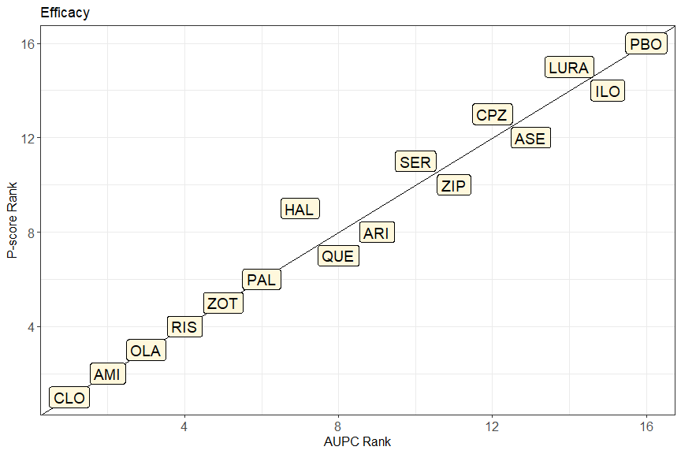

```r
# Extended P-scores at a single CIV of 0.30
eff_rank <- pscore_civs(
  x           = list(efficacy),
  CIVs        = 0.30,
  correlation = NULL,
  type        = "H"
)

# AUPC over a CIV range of 0.20 to 0.40
pscore_range <- pscore_civs(
  x           = list(efficacy),
  CIVs        = list(seq(0.2, 0.4, 0.1)),
  correlation = NULL,
  type        = "H"
)
aupc_res <- aupc(pscore_range)

plot_aupc_pscore(
  aupc         = aupc_res,
  pscore       = eff_rank,
  outcome_name = "Efficacy"
)
```

## Heatplot of Treatment Rankings

The `pscores_heatplot()` function visualizes treatment rankings across a grid of CIV combinations for **exactly two outcomes**. Each facet represents one treatment, with the two CIV axes on x and y and ranking shown as a colour gradient. This complements the AUPC summary by revealing the specific CIV regions where a treatment performs better or worse.

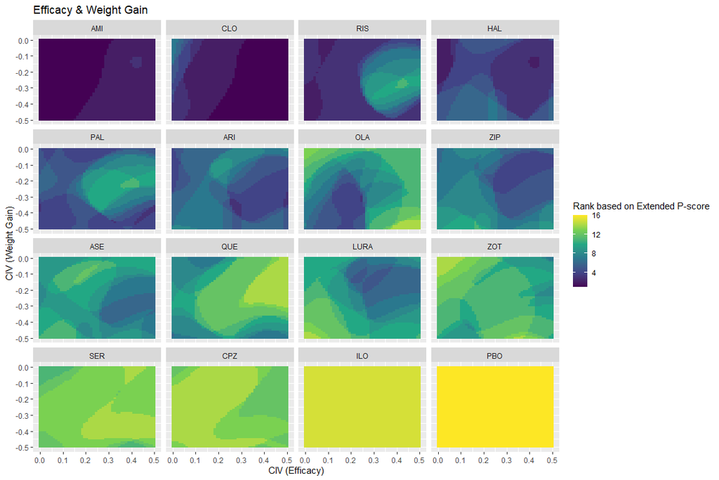

```r
pscores_heatplot(
  out,
  title    = "Efficacy & Weight Gain",
  outcome1 = "Efficacy",
  outcome2 = "Weight Gain"
)
```

> **Note:** `pscores_heatplot()` requires a `pscore_civs` object with exactly two outcomes. The `out` object computed in the previous section is used here directly.

## POTH Bubble Plot

The `pscores_pothplot()` function visualizes **Precision of Treatment Hierarchy (POTH)** values across a grid of CIV combinations for exactly two outcomes using a bubble plot. Bubble size reflects POTH magnitude, and the maximum and minimum values are optionally highlighted in distinct colours (blue and pink), revealing the CIV regions where treatment rankings are most or least precise.

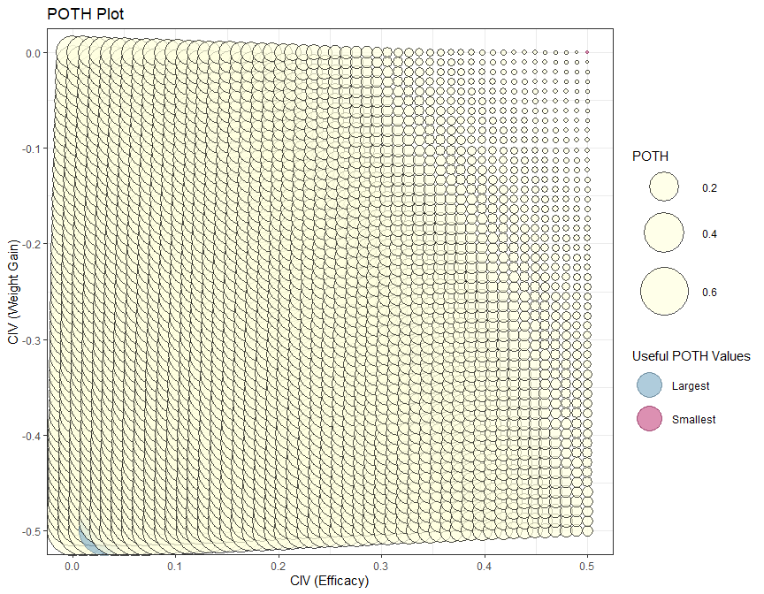

```r
g <- pscores_pothplot(
  x        = out,
  title    = "POTH Plot",
  outcome1 = "Efficacy",
  outcome2 = "Weight Gain"
)
```

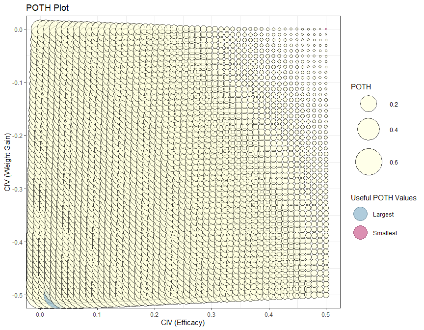

```
#>
#> $grid
#> # A tibble: 2,500 × 3
#> # Groups:   CIV1, CIV2 [2,500]
#>     CIV1   CIV2  POTH
#>    <dbl>  <dbl> <dbl>
#>  1     0 -0.5   0.655
#>  2     0 -0.490 0.654
#>  3     0 -0.480 0.653
#>  4     0 -0.469 0.652
#>  5     0 -0.459 0.649
#>  6     0 -0.449 0.646
#>  7     0 -0.439 0.642
#>  8     0 -0.429 0.637
#>  9     0 -0.418 0.631
#> 10     0 -0.408 0.624
#> # ℹ 2,490 more rows
```

```r
g
```

For large grids, use `newgridsize` to downsample to an n × n quantile grid for a cleaner visualization:

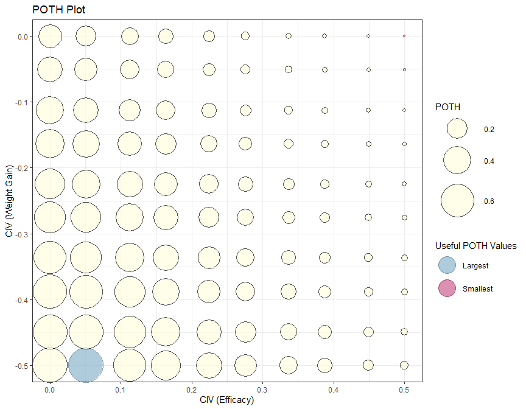

```r
g2 <- pscores_pothplot(
  x           = out,
  newgridsize = 10,
  title       = "POTH Plot",
  outcome1    = "Efficacy",
  outcome2    = "Weight Gain"
)
```

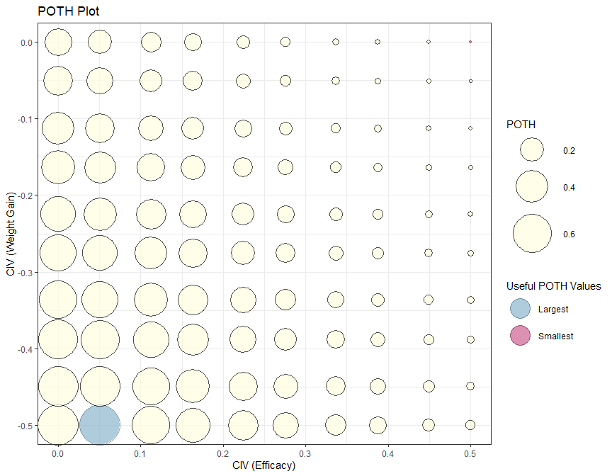

```
#>
#> $grid
#> # A tibble: 100 × 3
#> # Groups:   CIV1, CIV2 [100]
#>     CIV1    CIV2  POTH
#>    <dbl>   <dbl> <dbl>
#>  1     0 -0.5    0.655
#>  2     0 -0.449  0.646
#>  3     0 -0.388  0.610
#>  4     0 -0.337  0.569
#>  5     0 -0.276  0.523
#>  6     0 -0.224  0.489
#>  7     0 -0.163  0.443
#>  8     0 -0.112  0.393
#>  9     0 -0.0510 0.325
#> 10     0  0      0.272
#> # ℹ 90 more rows
```

```r
g2
```